# Oceňovanie európskych opcií: Black-Scholesov model a metóda Monte Carlo

Technická správa s aplikáciou na reálne dáta (AAPL)

Autor

Ian Spika

Publikované

30. októbra 2026

# 1 Úvod

Oceňovanie finančných derivátov patrí medzi najvýznamnejšie aplikácie matematiky v ekonómii. Európska kúpna opcia (call) dáva majiteľovi právo, nie však povinnosť, kúpiť podkladové aktívum za vopred dohodnutú cenu $K$ v stanovenom čase $T$. Otázka, koľko má taká opcia stáť dnes, viedla v roku 1973 k zverejneniu slávneho modelu, ktorý získal Nobelovu cenu za ekonómiu — Black-Scholesovho modelu (Black a Scholes 1973; Merton 1973).

Hoci pre vanilkové európske opcie existuje uzavretá analytická formula, v praxi sa stretávame s mnohými variantmi opcií (ázijské, bariérové, americké, koš opcií), pre ktoré vzorec neexistuje a nutne sa musíme uchýliť k numerickým metódam. Najflexibilnejšou z nich je metóda Monte Carlo, ktorú do oceňovania opcií zaviedol Boyle (1977).

Cieľom tejto správy je:

1. predstaviť teoretické pozadie Black-Scholesovho modelu,
2. implementovať obe metódy oceňovania v jazyku R,
3. empiricky overiť konvergenciu Monte Carlo odhadu k analytickej hodnote a kvantifikovať jeho štatistickú chybu,
4. ukázať, prečo je Monte Carlo nevyhnutné pre exotické opcie, na príklade ázijskej opcie,
5. **aplikovať obe metódy na reálne trhové dáta** akcie Apple Inc. (AAPL) a porovnať modelové ceny so skutočnými trhovými kotáciami, čo vedie ku konceptu *implikovanej volatility*.

# 2 Teoretické pozadie

## 2.1 Geometrický Brownov pohyb

Black-Scholesov model predpokladá, že cena podkladového aktíva $S_t$ sa riadi stochastickou diferenciálnou rovnicou

$$dS_t = \mu S_t\, dt + \sigma S_t\, dW_t,
\tag{1}$$

kde $\mu$ je očakávaný výnos, $\sigma$ volatilita a $W_t$ štandardný Wienerov proces. Riešením rovnice Rovnica 1 je geometrický Brownov pohyb

$$S_T = S_0 \exp\!\left[\left(\mu - \tfrac{1}{2}\sigma^{2}\right) T + \sigma W_T\right],
\tag{2}$$

čo plynie z Itôovej lemy (Hull 2018, kap. 14). Pre účely oceňovania v rizikovo-neutrálnej miere nahrádzame $\mu$ bezrizikovou úrokovou mierou $r$.

## 2.2 Black-Scholesova formula

Cena európskej kúpnej opcie podľa Black-Scholesovho modelu je

$$C_{\mathrm{BS}} = S_0\, \Phi(d_1) - K e^{-rT}\, \Phi(d_2),
\tag{3}$$

kde $\Phi$ je distribučná funkcia štandardného normálneho rozdelenia a

$$d_1 = \frac{\ln(S_0/K) + (r + \tfrac{1}{2}\sigma^2)T}{\sigma\sqrt{T}}, \qquad
d_2 = d_1 - \sigma\sqrt{T}.
\tag{4}$$

## 2.3 Monte Carlo oceňovanie

Cena opcie je v rizikovo-neutrálnej miere $\mathbb{Q}$ definovaná ako diskontovaná očakávaná výplata:

$$C = e^{-rT}\, \mathbb{E}^{\mathbb{Q}}\!\left[(S_T - K)^{+}\right].
\tag{5}$$

Monte Carlo odhad spočíva v generovaní $n$ nezávislých realizácií ceny $S_T^{(i)}$ podľa rovnice Rovnica 2 a v aproximácii očakávania aritmetickým priemerom:

$$\hat{C}_{\mathrm{MC}} = e^{-rT}\, \frac{1}{n} \sum_{i=1}^{n} \left(S_T^{(i)} - K\right)^{+}.
\tag{6}$$

Podľa centrálnej limitnej vety je štandardná chyba odhadu rádu $\mathcal{O}(1/\sqrt{n})$ a 95 % konfidenčný interval má tvar $\hat{C}_{\mathrm{MC}} \pm 1{,}96 \cdot \hat{s}/\sqrt{n}$, kde $\hat{s}$ je výberová smerodajná odchýlka diskontovaných výplat (Glasserman 2003, kap. 1).

# 3 Implementácia v R

## 3.1 Funkcie a parametre úlohy

Pre základnú validáciu metód použijeme modelové parametre typické pre krátkodobé akciové opcie. Reálne dáta AAPL spracujeme v Sekcia 5.

**Kód**

```r
S0    <- 100      # aktualna cena podkladu
K     <- 100      # realizacna cena (at-the-money)
r     <- 0.05     # bezrizikova urokova miera
sigma <- 0.20     # volatilita
T_    <- 1        # cas do expiracie (v rokoch)
```

**Kód**

```r
bs_call <- function(S0, K, r, sigma, T_) {
  d1 <- (log(S0 / K) + (r + 0.5 * sigma^2) * T_) / (sigma * sqrt(T_))
  d2 <- d1 - sigma * sqrt(T_)
  S0 * pnorm(d1) - K * exp(-r * T_) * pnorm(d2)
}

mc_call <- function(S0, K, r, sigma, T_, n, seed = NULL) {
  if (!is.null(seed)) set.seed(seed)
  Z       <- rnorm(n)
  ST      <- S0 * exp((r - 0.5 * sigma^2) * T_ + sigma * sqrt(T_) * Z)
  payoff  <- pmax(ST - K, 0)
  disc    <- exp(-r * T_) * payoff
  est     <- mean(disc)
  se      <- sd(disc) / sqrt(n)
  list(estimate = est, se = se,
       ci_lo = est - 1.96 * se, ci_hi = est + 1.96 * se)
}

C_bs <- bs_call(S0, K, r, sigma, T_)
mc_result <- mc_call(S0, K, r, sigma, T_, n = 100000, seed = 42)
```

Pre modelové parametre dostávame analytickú cenu $C_{\mathrm{BS}} = 10.4506$ a Monte Carlo odhad $\hat{C}_{\mathrm{MC}} = 10.4345$ s 95 % konfidenčným intervalom $[10.3433,\ 10.5257]$.

# 4 Validácia: konvergencia Monte Carlo odhadu

## 4.1 Tabuľka konvergencie

Aby sme overili rýchlosť konvergencie odhadu Rovnica 6, zopakujme simuláciu pre rôzne hodnoty $n$. Výsledky sú zhrnuté v Tabuľka 1.

**Kód**

```r
ns <- c(1e2, 1e3, 1e4, 1e5, 1e6)

tab <- do.call(rbind, lapply(ns, function(n) {
  res <- mc_call(S0, K, r, sigma, T_, n, seed = 2026)
  data.frame(n = n, odhad = res$estimate, se = res$se,
             chyba = abs(res$estimate - C_bs))
}))

knitr::kable(
  tab,
  col.names = c("n", "Odhad MC", "Štand. chyba", "|MC − BS|"),
  digits = 5, align = "rrrr"
)
```

Tabuľka 1: Konvergencia Monte Carlo odhadu k Black-Scholesovej cene.

| n | Odhad MC | Štand. chyba | \|MC − BS\| |
| --- | --- | --- | --- |
| 1e+02 | 9.27585 | 1.42180 | 1.17474 |
| 1e+03 | 10.51848 | 0.47218 | 0.06789 |
| 1e+04 | 10.49570 | 0.15020 | 0.04512 |
| 1e+05 | 10.50374 | 0.04678 | 0.05316 |
| 1e+06 | 10.44387 | 0.01471 | 0.00672 |

## 4.2 Grafická ilustrácia konvergencie

Konvergencia bodového odhadu spolu s pásmom 95 % konfidenčného intervalu je znázornená na Obrázok 1.

**Kód**

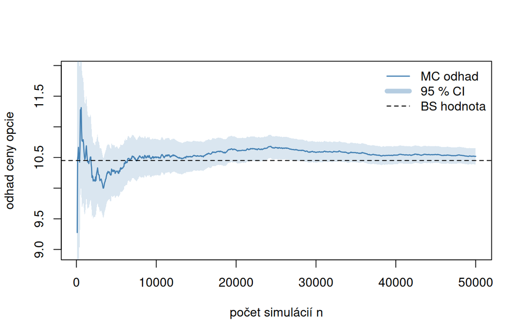

Obrázok 1: Konvergencia Monte Carlo odhadu ceny opcie k analytickej hodnote (čierna prerušovaná čiara) so zväčšujúcim sa počtom simulácií. Šedé pásmo predstavuje 95 % konfidenčný interval.

```r
set.seed(2026)
n_max  <- 50000
Z      <- rnorm(n_max)
ST     <- S0 * exp((r - 0.5 * sigma^2) * T_ + sigma * sqrt(T_) * Z)
disc   <- exp(-r * T_) * pmax(ST - K, 0)

cumul_mean <- cumsum(disc) / seq_along(disc)
cumul_var  <- (cumsum(disc^2) - seq_along(disc) * cumul_mean^2) /
              pmax(seq_along(disc) - 1, 1)
cumul_se   <- sqrt(cumul_var / seq_along(disc))

idx <- seq(100, n_max, by = 50)

plot(idx, cumul_mean[idx], type = "l", lwd = 1.5, col = "steelblue",
     ylim = c(C_bs - 1.5, C_bs + 1.5),
     xlab = "počet simulácií n", ylab = "odhad ceny opcie")
polygon(c(idx, rev(idx)),
        c(cumul_mean[idx] - 1.96 * cumul_se[idx],
          rev(cumul_mean[idx] + 1.96 * cumul_se[idx])),
        col = adjustcolor("steelblue", alpha.f = 0.2), border = NA)
abline(h = C_bs, lty = 2, lwd = 1.2)
legend("topright", legend = c("MC odhad", "95 % CI", "BS hodnota"),
       col = c("steelblue", adjustcolor("steelblue", 0.4), "black"),
       lty = c(1, 1, 2), lwd = c(1.5, 6, 1.2), bty = "n")
```

## 4.3 Bonus: ázijská opcia

Pre exotické opcie analytická formula vo všeobecnosti neexistuje a metóda Monte Carlo sa stáva nevyhnutnou. Ako príklad uvažujme **ázijskú priemerovaciu kúpnu opciu**, ktorej výplata závisí od priemeru ceny počas životnosti opcie:

$$\text{payoff} = \left(\overline{S} - K\right)^{+},
\qquad
\overline{S} = \frac{1}{m} \sum_{j=1}^{m} S_{t_j}.
\tag{7}$$

**Kód**

```r
mc_asian <- function(S0, K, r, sigma, T_, n, m, seed = NULL) {
  if (!is.null(seed)) set.seed(seed)
  dt <- T_ / m
  Z  <- matrix(rnorm(n * m), nrow = n, ncol = m)
  log_inc <- (r - 0.5 * sigma^2) * dt + sigma * sqrt(dt) * Z
  log_S   <- t(apply(log_inc, 1, cumsum))
  S_paths <- S0 * exp(log_S)
  S_avg   <- rowMeans(S_paths)
  payoff  <- pmax(S_avg - K, 0)
  disc    <- exp(-r * T_) * payoff
  list(estimate = mean(disc), se = sd(disc) / sqrt(n))
}

asian <- mc_asian(S0, K, r, sigma, T_, n = 50000, m = 50, seed = 7)
```

Cena ázijskej opcie ($5.8569$) je nižšia než cena európskej opcie ($10.4506$): priemerovanie znižuje volatilitu výplaty, a teda aj cenu opcie (Glasserman 2003, kap. 4).

# 5 Aplikácia na reálne dáta: Apple Inc.

V tejto sekcii aplikujeme obe metódy na akciu **Apple Inc. (NASDAQ: AAPL)**. Dáta sú stiahnuté zo služby Yahoo Finance pomocou packagu `quantmod` a uložené v adresári `data/`. V projekte sú dáta automaticky aktualizované každý deň cez GitHub Actions.

**Kód**

```r
prices  <- read.csv("data/aapl_prices.csv")
prices$date <- as.Date(prices$date)

# Meta-info
meta_lines <- readLines("data/meta.txt")
meta <- setNames(
  trimws(sub("^[^:]+:\\s*", "", meta_lines)),
  trimws(sub(":.*$", "", meta_lines))
)

S0_real     <- as.numeric(meta["spot_price"])
spot_date   <- meta["spot_date"]
fetched_at  <- meta["fetched_at"]
```

Aktuálna cena akcie ku dňu **2026-10-29** je **$348.91**.

## 5.1 Vývoj ceny akcie

Obrázok 2 zobrazuje vývoj ceny AAPL za posledné 2 roky.

**Kód**

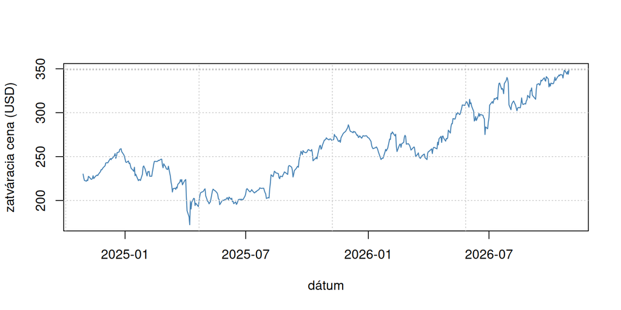

Obrázok 2: Vývoj zatváracej ceny AAPL za posledné 2 roky. Dáta: Yahoo Finance.

```r
plot(prices$date, prices$close, type = "l", lwd = 1.2, col = "steelblue",
     xlab = "dátum", ylab = "zatváracia cena (USD)",
     main = "")
grid(col = "gray80")
abline(h = S0_real, lty = 3, col = "darkgray")
```

## 5.2 Odhad volatility z historických dát

Volatilita $\sigma$ je v Black-Scholesovom modeli kľúčový parameter, ktorý nie je priamo pozorovateľný. Tradičný spôsob jej odhadu je z historických logaritmických denných výnosov

$$r_t = \ln\!\frac{S_t}{S_{t-1}}.
\tag{8}$$

Anualizovaná volatilita sa získa škálovaním smerodajnej odchýlky denných výnosov faktorom $\sqrt{252}$, kde 252 je typický počet obchodných dní v roku.

**Kód**

```r
log_returns <- diff(log(prices$close))
log_returns <- log_returns[is.finite(log_returns)]
sigma_daily <- sd(log_returns)
sigma_hist  <- sigma_daily * sqrt(252)

mu_daily    <- mean(log_returns)
mu_annual   <- mu_daily * 252
```

Empirické hodnoty:

- denná smerodajná odchýlka výnosov: $0.0180$
- **anualizovaná historická volatilita:** $\hat\sigma_{\mathrm{hist}} = 0.2857$ (28.57 %)
- anualizovaný priemerný výnos: $0.2098$

## 5.3 Test predpokladu normality

Black-Scholesov model predpokladá, že logaritmické výnosy sú normálne rozdelené. Obrázok 3 porovnáva empirické rozdelenie výnosov AAPL s prispôsobenou normálnou hustotou.

**Kód**

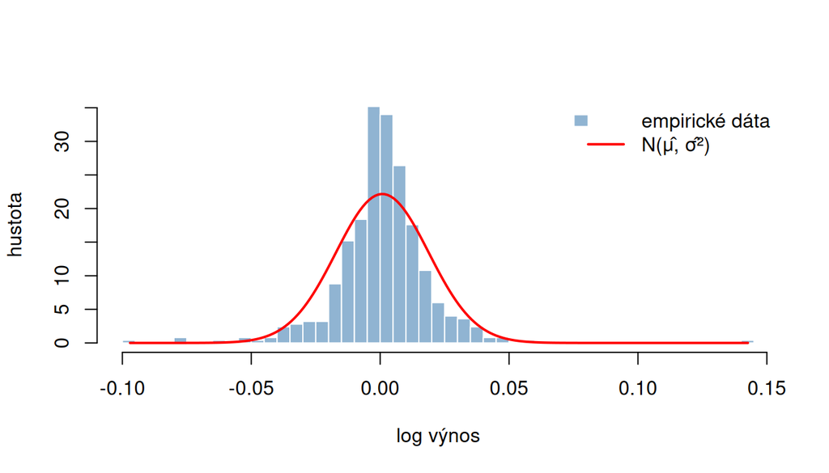

Obrázok 3: Histogram denných logaritmických výnosov AAPL s nadprispôsobenou normálnou hustotou (červená čiara). Empirické dáta vykazujú výraznejšie chvosty než predpokladá normálne rozdelenie — znak tzv. *fat tails*, dobre známy problém Black-Scholesovho modelu.

```r
hist(log_returns, breaks = 50, freq = FALSE,
     col = adjustcolor("steelblue", 0.6), border = "white",
     xlab = "log výnos", ylab = "hustota", main = "")
xs <- seq(min(log_returns), max(log_returns), length.out = 200)
lines(xs, dnorm(xs, mean = mu_daily, sd = sigma_daily),
      col = "red", lwd = 2)
legend("topright",
       legend = c("empirické dáta", "N(μ̂, σ̂²)"),
       fill = c(adjustcolor("steelblue", 0.6), NA),
       border = c("white", NA),
       lty = c(NA, 1), col = c(NA, "red"), lwd = c(NA, 2),
       bty = "n")
```

Vizuálne aj kvantitatívne (Jarque-Bera test, p-hodnota < $0e+00$) zamietame normalitu výnosov. Špicatosť (kurtóza) je výrazne vyššia než 3 — extrémne pohyby na trhu sa vyskytujú častejšie, než by predpovedalo normálne rozdelenie. Tento jav sa nazýva *fat tails* a je jednou z hlavných výhrad voči Black-Scholesovmu modelu.

## 5.4 Porovnanie modelových cien s trhovými

Teraz aplikujeme obe metódy na konkrétnu sériu kúpnych opcií na AAPL. Dáta sú stiahnuté z aktuálneho option chain.

**Kód**

```r
options_path <- "data/aapl_options.csv"
have_options <- file.exists(options_path) &&
                file.size(options_path) > 0
```

**Kód**

```r
opts <- read.csv(options_path)

T_real <- as.numeric(meta["years_to_expiry"])
expiry <- meta["option_expiry"]
r_real <- 0.045   # bezrizikova miera ~ 3M T-bill yield

# Implikovana volatilita: hladame sigma t.z. BS(sigma) = market_price.
# Vraciame NA ak cena lezi mimo arbitrážnych hranic alebo bisekcia zlyha.
implied_vol <- function(market_price, S0, K, r, T_) {
  if (is.na(market_price) || market_price <= 0) return(NA_real_)
  # Arbitražne hranice: max(0, S - K*e^-rT) <= C <= S
  lower <- max(0, S0 - K * exp(-r * T_))
  if (market_price < lower * 0.99 || market_price > S0) return(NA_real_)

  f <- function(sigma) bs_call(S0, K, r, sigma, T_) - market_price
  # Hladame v intervale (1%, 300%)
  tryCatch({
    res <- uniroot(f, interval = c(0.01, 3.0), tol = 1e-6)
    res$root
  }, error = function(e) NA_real_)
}

# Pre kazdu opciu spocitame: BS cenu, MC cenu, IV
opts$bs_hist <- bs_call(S0_real, opts$strike, r_real, sigma_hist, T_real)

opts$mc_hist <- sapply(opts$strike, function(K_i) {
  res <- mc_call(S0_real, K_i, r_real, sigma_hist, T_real,
                 n = 50000, seed = 1)
  res$estimate
})

opts$iv_implied <- mapply(function(price, K_i) {
  implied_vol(price, S0_real, K_i, r_real, T_real)
}, opts$market_price, opts$strike)

opts$diff_bs <- opts$market_price - opts$bs_hist
```

**Kód**

```r
display_tab <- data.frame(
  Strike     = opts$strike,
  Bid        = opts$bid,
  Ask        = opts$ask,
  Last       = opts$last,
  Trh        = opts$market_price,
  BS         = opts$bs_hist,
  MC         = opts$mc_hist,
  Rozdiel    = opts$diff_bs,
  IV         = opts$iv_implied
)

knitr::kable(display_tab,
             col.names = c("K", "Bid", "Ask", "Last", "Cena trhu",
                           "BS (σ_hist)", "MC (σ_hist)",
                           "Trh − BS", "IV"),
             digits = 4, align = "r")
```

Tabuľka 2: Porovnanie trhových cien call opcií na AAPL s modelovými cenami. *Cena trhu* je mid (bid+ask)/2 ak je trh otvorený, inak posledná obchodovaná cena. *BS* a *MC* používajú historickú volatilitu. *IV* je implikovaná volatilita získaná inverziou Black-Scholesovej formule.

| K | Bid | Ask | Last | Cena trhu | BS (σ_hist) | MC (σ_hist) | Trh − BS | IV |
| --- | --- | --- | --- | --- | --- | --- | --- | --- |
| 320 | 30.35 | 31.00 | 30.50 | 30.675 | 34.4385 | 34.4345 | -3.7635 | NA |
| 325 | 26.55 | 27.35 | 26.95 | 26.950 | 30.5847 | 30.5941 | -3.6347 | 0.1699 |
| 330 | 22.95 | 23.75 | 23.35 | 23.350 | 26.9614 | 26.9831 | -3.6114 | 0.1910 |
| 335 | 19.45 | 19.85 | 20.00 | 19.650 | 23.5860 | 23.6163 | -3.9360 | 0.1942 |
| 340 | 16.25 | 16.90 | 16.75 | 16.575 | 20.4719 | 20.5122 | -3.8969 | 0.2027 |
| 345 | 13.75 | 14.10 | 13.85 | 13.925 | 17.6271 | 17.6704 | -3.7021 | 0.2110 |
| 350 | 11.00 | 11.30 | 11.30 | 11.150 | 15.0548 | 15.1006 | -3.9048 | 0.2089 |
| 355 | 8.85 | 9.10 | 8.95 | 8.975 | 12.7525 | 12.7976 | -3.7775 | 0.2114 |
| 360 | 6.85 | 7.20 | 7.20 | 7.025 | 10.7134 | 10.7557 | -3.6884 | 0.2113 |
| 365 | 5.30 | 5.60 | 5.55 | 5.450 | 8.9259 | 8.9715 | -3.4759 | 0.2122 |
| 370 | 4.05 | 4.30 | 4.17 | 4.175 | 7.3753 | 7.4251 | -3.2003 | 0.2132 |
| 375 | 3.00 | 3.15 | 3.10 | 3.075 | 6.0439 | 6.0986 | -2.9689 | 0.2120 |
| 380 | 2.26 | 2.40 | 2.35 | 2.330 | 4.9125 | 4.9684 | -2.5825 | 0.2144 |
| 385 | 1.61 | 1.75 | 1.70 | 1.680 | 3.9605 | 4.0166 | -2.2805 | 0.2141 |
| 390 | 1.18 | 1.29 | 1.24 | 1.235 | 3.1674 | 3.2229 | -1.9324 | 0.2158 |
| 395 | 0.85 | 0.96 | 0.90 | 0.905 | 2.5132 | 2.5634 | -1.6082 | 0.2177 |
| 400 | 0.62 | 0.68 | 0.67 | 0.650 | 1.9786 | 2.0279 | -1.3286 | 0.2190 |
| 405 | 0.46 | 0.54 | 0.47 | 0.500 | 1.5458 | 1.5926 | -1.0458 | 0.2235 |
| 410 | 0.33 | 0.42 | 0.33 | 0.375 | 1.1986 | 1.2407 | -0.8236 | 0.2268 |
| 415 | 0.25 | 0.33 | 0.27 | 0.290 | 0.9226 | 0.9596 | -0.6326 | 0.2312 |
| 420 | 0.18 | 0.23 | 0.24 | 0.205 | 0.7050 | 0.7376 | -0.5000 | 0.2323 |
| 425 | 0.12 | 0.19 | 0.16 | 0.155 | 0.5350 | 0.5596 | -0.3800 | 0.2357 |
| 430 | 0.08 | 0.14 | 0.14 | 0.110 | 0.4031 | 0.4205 | -0.2931 | 0.2370 |
| 435 | 0.05 | 0.13 | 0.10 | 0.090 | 0.3017 | 0.3124 | -0.2117 | 0.2426 |
| 440 | 0.03 | 0.14 | 0.12 | 0.085 | 0.2244 | 0.2279 | -0.1394 | 0.2520 |
| 445 | 0.03 | 0.14 | 0.09 | 0.085 | 0.1658 | 0.1646 | -0.0808 | 0.2629 |

**Poznámka**

Zdroj cien: mid (bid+ask)/2 · Posledná aktualizácia dát: 2026-10-30 20:15:20.72137

## 5.5 Volatility smile

Implikovaná volatilita ako funkcia strike-u zvyčajne nie je konštantná, hoci Black-Scholesov model predpokladá opak. Empiricky pozorovaný tvar sa nazýva **volatility smile** alebo **smirk** (Hull 2018, kap. 20).

**Kód**

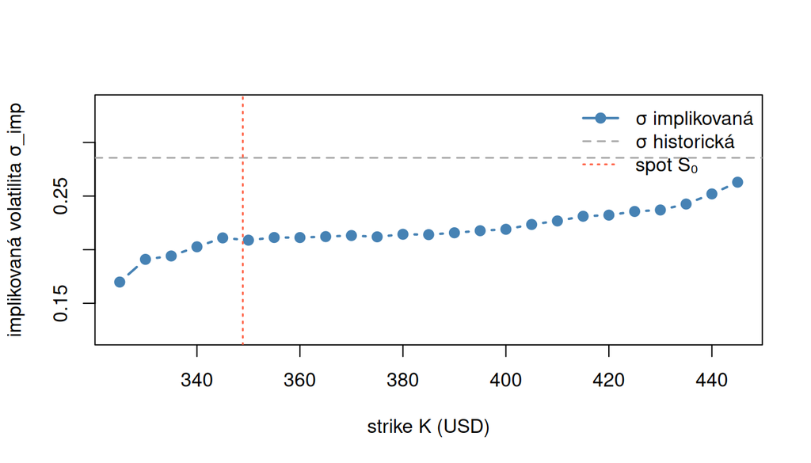

Obrázok 4: Implikovaná volatilita call opcií AAPL ako funkcia strike-u. Vodorovná čiara označuje historickú volatilitu odhadnutú z výnosov za posledné 2 roky. Zakrivený tvar (smile/smirk) je znakom, že trh oceňuje extrémne pohyby vyššie, než predpokladá Black-Scholesov model s konštantnou volatilitou.

```r
valid <- !is.na(opts$iv_implied) & opts$iv_implied > 0.05 & opts$iv_implied < 2.0

if (sum(valid) >= 3) {
  # Auto-skala s rozumnym minimom
  iv_range <- range(c(opts$iv_implied[valid], sigma_hist), na.rm = TRUE)
  y_lo <- max(0, iv_range[1] - 0.05)
  y_hi <- iv_range[2] + 0.05

  plot(opts$strike[valid], opts$iv_implied[valid],
       type = "b", pch = 19, col = "steelblue", lwd = 2,
       ylim = c(y_lo, y_hi),
       xlab = "strike K (USD)", ylab = "implikovaná volatilita σ_imp")
  abline(h = sigma_hist, lty = 2, col = "darkgray", lwd = 1.5)
  abline(v = S0_real, lty = 3, col = "tomato", lwd = 1.5)
  legend("topright",
         legend = c("σ implikovaná", "σ historická", "spot S₀"),
         col = c("steelblue", "darkgray", "tomato"),
         lty = c(1, 2, 3), lwd = c(2, 1.5, 1.5),
         pch = c(19, NA, NA), bty = "n")
} else {
  plot.new()
  text(0.5, 0.5,
       sprintf("Nedostatok validných opcií pre smile graf (%d).\nSkúste rerun keď je trh otvorený.",
               sum(valid)),
       cex = 1.1)
}
```

## 5.6 Diskusia výsledkov

Tieto pozorovania motivujú ďalší vývoj v oblasti finančnej matematiky: modely so stochastickou volatilitou (Heston), modely s skokmi (Merton-jump-diffusion) a lokálnou volatilitou (Dupire).

# 6 Záver

V tejto správe sme porovnali dve metódy oceňovania európskej kúpnej opcie: analytickú Black-Scholesovu formulu a numerickú Monte Carlo simuláciu. Empiricky sme overili teoretickú rýchlosť konvergencie $\mathcal{O}(1/\sqrt{n})$ — pri $n = 10^6$ sa Monte Carlo odhad líši od analytickej hodnoty rádovo o tisíciny.

Tieto pozorovania zhrnujú jeden z najdôležitejších poznatkov modernej finančnej matematiky: hoci je Black-Scholes elegantný a stále základným nástrojom, jeho predpoklady sú v reálnom svete porušené, a praktické oceňovanie vyžaduje pokročilejšie modely. Monte Carlo simulácia pritom zostáva univerzálnym nástrojom — funguje rovnako pre Black-Scholes ako aj pre Heston či Merton-jump-diffusion, kde uzavreté formule neexistujú.

Ďalšie smery, ktorými by sa práca dala rozšíriť, zahŕňajú: techniky redukcie rozptylu (antitetické a kontrolné premenné), oceňovanie amerických opcií metódou Longstaff-Schwartz, alebo kalibráciu modelu so stochastickou volatilitou (Glasserman 2003).

## Literatúra

BLACK, Fischer a Myron SCHOLES, 1973. The Pricing of Options and Corporate Liabilities. *Journal of Political Economy*. 1973, roč. 81, č. 3, s. 637–654.

BOYLE, Phelim P., 1977. Options: A Monte Carlo Approach. *Journal of Financial Economics*. 1977, roč. 4, č. 3, s. 323–338.

GLASSERMAN, Paul, 2003. *Monte Carlo Methods in Financial Engineering*. New York: Springer. ISBN 978-0-387-00451-8.

HULL, John C., 2018. *Options, Futures, and Other Derivatives*. 10. vyd. New York: Pearson. ISBN 978-0-13-447208-9.

MERTON, Robert C., 1973. Theory of Rational Option Pricing. *The Bell Journal of Economics and Management Science*. 1973, roč. 4, č. 1, s. 141–183.